# Pribilof Islands ice cover exploration.

### Library imports, file paths and the like.

```python
%matplotlib inline
from __future__ import print_function
import os, os.path, glob
import datetime
import numpy as np
import matplotlib as mpl
import matplotlib.pyplot as plt
import matplotlib.dates as mdates
from matplotlib.patches import Rectangle, Polygon
from matplotlib.dates import YearLocator, MonthLocator, DateFormatter
from mpl_toolkits.basemap import Basemap
from mpl_toolkits.axes_grid1 import make_axes_locatable
from pygaarst import raster
```

```python
font = {'family' : 'Calibri',
        'weight' : 'bold',
        'size'   : 16}
mpl.rc('font', **font)
```

```python
reload(raster)
```

```
<module 'pygaarst.raster' from '/Users/chris/Dropbox/Research/pygaarst/pygaarst/raster.pyc'>
```

```python
datadir = "/Volumes/SCIENCE/Ice/DATA_BY_AREA/NorthCryo_SeaIce/projects/Searchlight/production/data/NSIDC_Data_09080153072/Sea_Ice_Concentrations_from_Nimbus-7_SMMR_and_DMSP_SSM_I-SSMIS_Passive_Microwave"
outdir = "/Volumes/SCIENCE/Ice/RESULTS_BY_AREA/"
testfn = 'nt_20120131_f17_v01_n.bin.reproj.tif'
testpath = os.path.join(datadir, testfn)
```

As the file name encodes the date, we can recover the date the data was acquired.

```python
def fn2date(filepath):
    head, tail = os.path.split(filepath)
    dt = datetime.datetime.strptime(tail[3:11], '%Y%m%d').date()
    return datetime.datetime.strftime(dt, "%Y-%m-%d")
```

```python
fn2date(testpath)
```

```
'2012-01-31'
```

### Get data

A variable to access the test dataset.

```python
nsdic = raster.GeoTIFF(testpath)
```

The scene has 448 by 304 pixels.

```python
nsdic.nrow, nsdic.ncol
```

```
(448, 304)
```

As explained in the documentation (http://nsidc.org/data/docs/daac/nsidc0051_gsfc_seaice.gd.html#data_description), the data are 8-bit unsigned integers with allowed values between 0 and 255:

- The values 0 to 250 are scaled integers represent the average sea ice concentration in the pixel (divide by 2.5 to get percentages).
- The values 251 to 255 are flags indicating pixels affected by conditions such as the circular mask around the poles, the continental land mass, the coast line, or missing data.

We'll separate the data set up into two to make it easier to plot and associate color schemes with these.

```python
icedat = np.empty_like(nsdic.data)
icedat[:] = nsdic.data/2.5
icedat[icedat > 250] = 255
maskdat = np.empty_like(nsdic.data)
maskdat = np.ma.MaskedArray(nsdic.data, mask=nsdic.data <= 250)
```

### Geo-stuff: plot overview of the data globally

The data come in polar stereographic projection on the WGS 84 datum and spheroid. The central meridian is 45 degrees West (that is, this is the direction pointing downwards on the map).

```python
nsdic.projection
```

```
'PROJCS["unnamed",GEOGCS["WGS 84",DATUM["WGS_1984",SPHEROID["WGS 84",6378137,298.257223563,AUTHORITY["EPSG","7030"]],AUTHORITY["EPSG","6326"]],PRIMEM["Greenwich",0],UNIT["degree",0.0174532925199433],AUTHORITY["EPSG","4326"]],PROJECTION["Polar_Stereographic"],PARAMETER["latitude_of_origin",70],PARAME…
```

Coordinates of the scene upper left and lower corners (in m) as well as the grid spacing (25 km).

```python
nsdic.ulx, nsdic.uly, nsdic.lrx, nsdic.lry, nsdic.delx, nsdic.dely
```

```
(-3849918.534, 5849875.662, 3750081.466, -5350124.338, 25000.0, -25000.0)
```

A color map consisting of some grey values is defined for the mask array. Then both arrays are plotted.

```python
mask_vals = np.zeros((5, 4))
mask_vals[4] = [1, 1, 1, 0]
mask_vals[3] = [0.7, 0.7, 0.7, 1]
mask_vals[2] = [0.55, 0.55, 0.55, 1]
mask_vals[1] = [1, 1, 1, 0]
mask_vals[0] = [0.5, 0.5, 0.5, 1]
customcmap = mpl.colors.LinearSegmentedColormap.from_list("custommask", mask_vals)
```

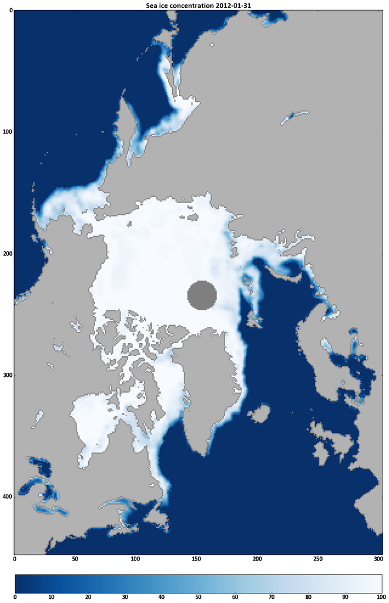

```python
f, ax = plt.subplots(figsize=(20, 30))
plt1 = ax.imshow(icedat, cmap="Blues_r", vmin=0, vmax=100, interpolation='nearest')
plt2 = ax.imshow(maskdat, vmin=251, vmax=255, cmap=customcmap, interpolation='nearest')
plt.colorbar(plt1, orientation='horizontal', pad = 0.03, shrink=0.83)
plt.title("Sea ice concentration %s" % fn2date(testpath))
im = ax.axis('image')
```

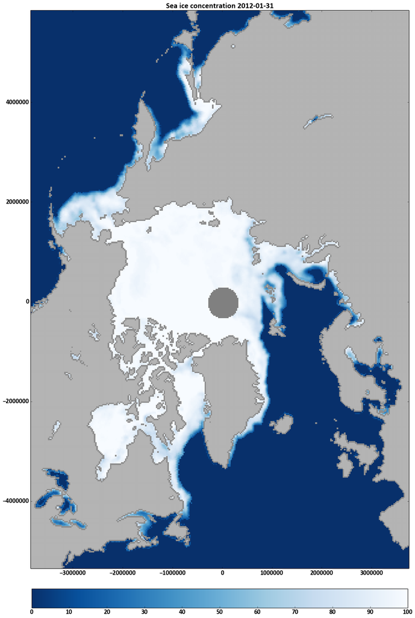

```python
f, ax = plt.subplots(figsize=(20, 30))
plt1 = ax.pcolormesh(nsdic._XY[0], nsdic._XY[1], np.flipud(icedat), cmap="Blues_r", vmin=0, vmax=100)
plt2 = ax.pcolormesh(nsdic._XY[0], nsdic._XY[1], np.flipud(maskdat), vmin=251, vmax=255, cmap=customcmap)
plt.colorbar(plt1, orientation='horizontal', pad = 0.03, shrink=0.83)
plt.title("Sea ice concentration %s" % fn2date(testpath))
im = ax.axis('image')
```

The whole dataset can also be plotted on a map. For this, we use the latitude and longitude values corresponding to the projected coordinates, and the Matplotlib Basemap toolkit to transform them back to a suitable projected coordinate system, for example, polar stereographic projection.

```python
Lon, Lat = nsdic.Lon, nsdic.Lat
```

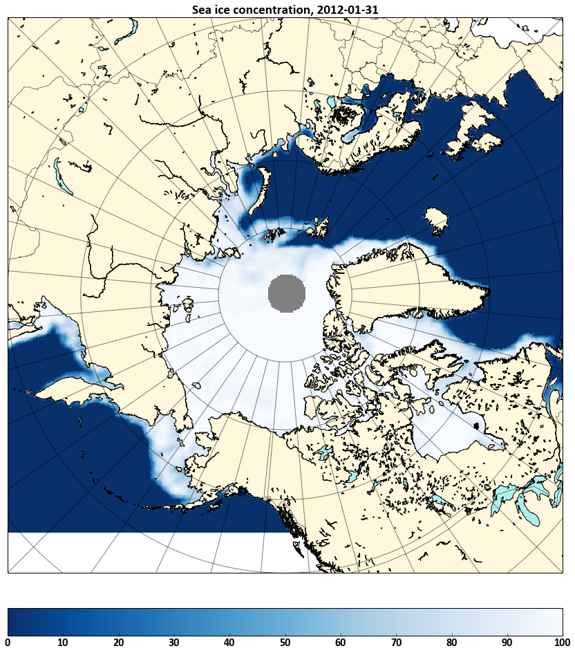

```python
SAVEOUT = False

water='paleturquoise'
earth='cornsilk'

fig = plt.figure(figsize=(18, 18))
plt.title("Sea ice concentration, %s" % fn2date(testpath))
m = Basemap(projection='npstere', boundinglat=50, lon_0=-135, lat_ts=70, resolution='i')
x, y = m(Lon, Lat)
implt = m.pcolormesh(x, y, np.flipud(icedat), cmap="Blues_r", vmin=0, vmax=100, edgecolor='none')
implt2 = m.pcolormesh(x, y, np.flipud(maskdat), vmin=251, vmax=255, cmap=customcmap)
m.drawcountries()
m.fillcontinents(lake_color=water, color=earth)
m.drawcoastlines(zorder=10)
m.drawmeridians(np.arange(-180, 180, 10))
m.drawparallels(np.arange(30, 80, 10))
plt.colorbar(implt, orientation='horizontal', pad=0.05, shrink=0.8)
if SAVEOUT:
    outfn = "testmap_NStere20120131_pcol.png"
    outpath = os.path.join(outdir, outfn)
    plt.savefig(outpath, dpi=200, bbox_inches='tight')
```

### Plot Pribiloff Island area

The latitude and longitude of St George and St Paul Islands.

```python
lat_pribStG, lon_pribStG = 56.583333, -169.583333
lat_pribStP, lon_pribStP = 57.183333, -170.266667
```

The coordtransform attribute is a function that transforms between (lon, lat) pairs and (easting, northing) pairs in the projectected coordinate system.

```python
geog2stereo = nsdic.coordtrans
```

We can use it to get the coordinates of the islands in the native polar stereographic projection.

```python
x_pribStG, y_pribStG = geog2stereo(lon_pribStG, lat_pribStG)
x_pribStP, y_pribStP = geog2stereo(lon_pribStP, lat_pribStP)
print(x_pribStG, y_pribStG)
```

```
-3064345.37522 2112634.92523
```

The i, j coordinates of the islands can be calculated directly. However, pygaarst offers a method on the GeoTIFF object with the argument `precise=True`, which returns the values as floating point.

```python
i_pribStG, j_pribStG = nsdic.xy2ij(x_pribStG, y_pribStG, precise=True)
i_pribStP, j_pribStP = nsdic.xy2ij(x_pribStP, y_pribStP, precise=True)
```

```python
print(i_pribStG, j_pribStG)
print(i_pribStP, j_pribStP)
```

```
149.489629471 31.4229263512
149.662558439 34.7426765501
```

Instead of the fractional location in the (i, j) coordinate system, we could also have used the pixel number. These are integers.

```python
i_intStG, j_intStG = nsdic.xy2ij(x_pribStG, y_pribStG)
i_intStP, j_intStP = nsdic.xy2ij(x_pribStP, y_pribStP)

print(i_intStG, j_intStG)
print(i_intStP, j_intStP)
```

```
149 31
149 34
```

Locating the Pribilofs on the dataset...

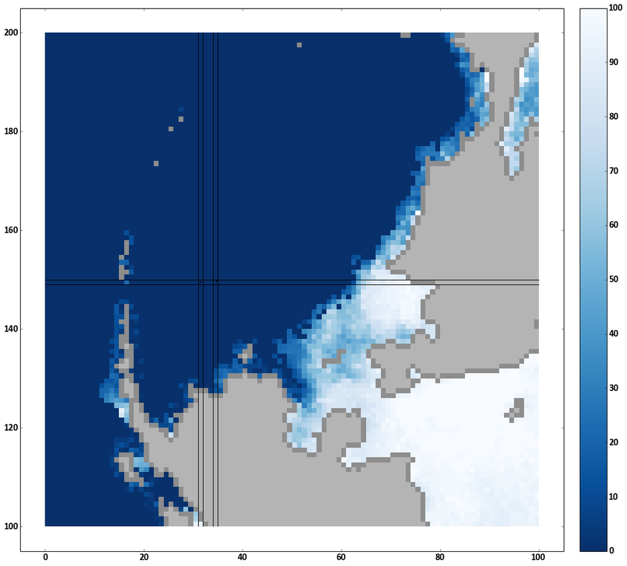

```python
f, ax = plt.subplots(figsize=(15, 15))
implt1 = ax.pcolor(np.arange(101), np.arange(200, 99, -1), icedat[100:200, 0:100], cmap="Blues_r", vmin=0, vmax=100)
implt2 = ax.pcolor(np.arange(101), np.arange(200, 99, -1), maskdat[100:200, 0:100], vmin=251, vmax=255, cmap=customcmap)
ax.scatter(j_pribStG, i_pribStG, marker='o', c='k', s=3, facecolors=None)
ax.scatter(j_pribStP, i_pribStP, marker='o', c='k', s=3, facecolors=None)
ax.vlines([31, 32, 34, 35], 100, 200)
ax.hlines(149, 0, 100)
ax.hlines(150, 0, 100)
# colorbar same height as image
divider = make_axes_locatable(plt.gca())
cax = divider.append_axes("right", "5%", pad="3%")
plt.colorbar(implt1, cax=cax)

plt.tight_layout()
ax.legend(scatterpoints=1,
          loc='upper left',)
axes = ax.axis('image')
```

To assess sea ice concentration between St. Paul and St. George Islands, we can either look at the 4 pixels that directly connect the two islands or a larger 3x4 rectangular area.

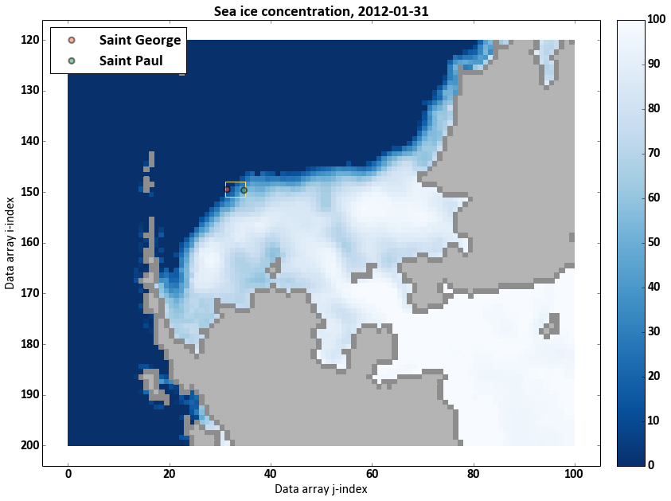

```python
SAVEOUT = False
font = {'family' : 'Calibri',
        'weight' : 'bold',
        'size'   : 16}
mpl.rc('font', **font)

rectangle = Rectangle((31, 148), width=4, height=3, fill=False, ec='khaki')

f, ax = plt.subplots(figsize=(12, 10))
implt1 = ax.pcolormesh(np.arange(101), np.arange(120, 201), icedat[120:200, 0:100], cmap="Blues_r", vmin=0, vmax=100)
implt2 = ax.pcolormesh(np.arange(101), np.arange(120, 201), maskdat[120:200, 0:100], vmin=251, vmax=255, cmap=customcmap)
ax.set_ylim(ax.get_ylim()[::-1])
ax.scatter(j_pribStG, i_pribStG, marker='o', c='tomato', s=50, linewidths=2, label='Saint George', alpha=0.5, zorder=5)
ax.scatter(j_pribStP, i_pribStP, marker='o', c='seagreen', s=50, linewidths=2, label='Saint Paul', alpha=0.5, zorder=5)
# colorbar same height as image
divider = make_axes_locatable(plt.gca())
cax = divider.append_axes("right", "5%", pad="3%")
plt.colorbar(implt1, cax=cax)
ax.set_title("Sea ice concentration, %s" % fn2date(testpath))
ax.set_xlabel('Data array j-index')
ax.set_ylabel('Data array i-index')
ax.add_patch(rectangle)
plt.tight_layout()
#plt.colorbar(implt1, ax=ax, orientation='horizontal', pad = 0.03, shrink=0.83)
ax.legend(scatterpoints=1,
          loc='upper left',)
axes = ax.axis('image')
if SAVEOUT:
    outfn = "testplot_NStere%s_zoom01.png" % fn2date(testpath)
    outpath = os.path.join(outdir, outfn)
    plt.savefig(outpath, dpi=100, bbox_inches='tight')
    plt.close()
```

Zooming in on a map, with rectangle marked.

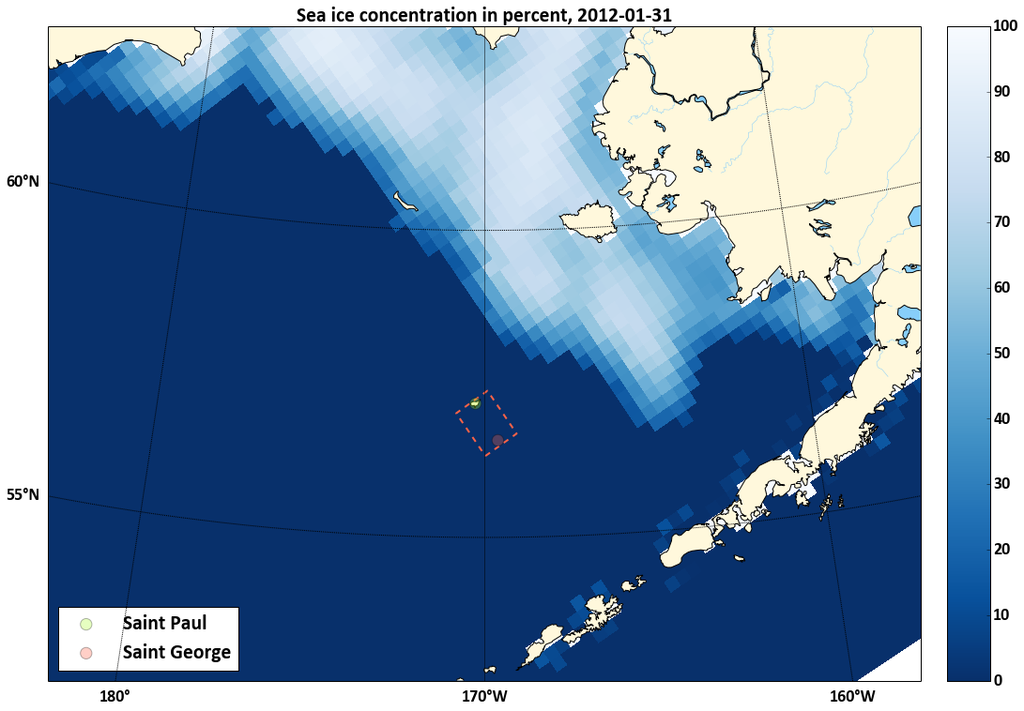

```python
width = rectangle.get_width()
height = rectangle.get_height()
orig = rectangle.get_xy()

def rectanglepath(topleftij, width, height):
    ii, jj = topleftij

    a1 = [(i, jj) for i in range(ii, ii+width+1)]
    a2 = [(ii+width, j) for j in range(jj+1, jj+height+1)]
    a3 = [(i, jj+height) for i in range(ii+width-1, ii-1, -1)]
    a4 = [(ii, j) for j in range(jj+height, jj-1, -1)]

    return a1 + a2 + a3 + a4

iijj = rectanglepath((orig[1], orig[0]), height, width)
xxyy = [nsdic.ij2xy(ii, jj) for (ii, jj) in iijj]
lonlat = [nsdic.coordtrans(x, y, inverse=True)  for (x, y) in xxyy]

SAVEOUT=True

font = {'family' : 'Calibri',
        'weight' : 'bold',
        'size'   : 18}
mpl.rc('font', **font)

water='lightskyblue'
earth='cornsilk'

fig = plt.figure(figsize=(18, 15))
bmap = Basemap(width=1600000, height=1200000, resolution='i', projection='aea', lat_1=50., lat_2=70., lat_0=58., lon_0=-170.)
x, y = bmap(Lon, Lat)
implt = bmap.pcolormesh(x, y, np.flipud(icedat), cmap="Blues_r", vmin=0, vmax=100, edgecolor='none')
x, y = bmap(lon_pribStP, lat_pribStP)
bmap.scatter(x, y, marker='o', c='greenyellow', s=150, zorder=20, label='Saint Paul', alpha=0.3)
x, y = bmap(lon_pribStG, lat_pribStG)
bmap.scatter(x, y, marker='o', c='tomato', s=150, zorder=20, label='Saint George', alpha=0.3)
xy = [bmap(l1, l2) for (l1, l2) in lonlat]
p = Polygon(xy, edgecolor='tomato', fill=False, linewidth=2, linestyle='dashed', zorder=15)
plt.gca().add_patch(p)
bmap.drawcoastlines(zorder=10)
bmap.drawrivers(color=water)
bmap.fillcontinents(lake_color=water, color=earth)
bmap.drawmeridians(np.arange(-180, -50, 10), labels=[1, 0, 0, 1], zorder=20)
bmap.drawparallels(np.arange(30, 80, 5), labels=[1, 0, 0, 1], zorder=20)
plt.title("Sea ice concentration in percent, %s" % fn2date(testpath))
plt.legend(scatterpoints=1,
          loc='lower left',)
divider = make_axes_locatable(plt.gca())
cax = divider.append_axes("right", "5%", pad="3%")
plt.colorbar(implt1, cax=cax)

if SAVEOUT:
    outfn = "NStere%s_pcol_zoom.png" % fn2date(testpath)
    outpath = os.path.join(outdir, outfn)
    plt.savefig(outpath, dpi=200, bbox_inches='tight')
```

### Ice indices

Calculating ice indices for months November, December, January, February, March, April, May. For data before the 1987/1988 winter, we have sea ice coverage every *second* day. After that, every day, during these months. Sea ice is zero at the Pribilofs during the summer.

How should we quantify the sea ice cover? We can either average the sea ice cover percentages, for example over a month, either along the straight line between the islands or within the rectangle. Or we can count days during which sea ice cover is non-zero (or above a threshold) and sum them up during a November-May season.

Below I calculate and plot the following indices:

- monthly averages for sea ice cover percentage (pixels directly between islands)
- monthly averages for sea ice cover percentage (pixels in 3x4 rectangle)
- number of days during a winter season where *all* pixels on the straight line between the islands are ice-covered
- number of days where *any* pixels on the straight line between the islands are ice-covered

How to loop through months.

```python
years = range(1978, 2013)
months = range(1, 6) + [11, 12]
allmonths = [(year, month) for year in years for month in months if (year, month ) > (1978, 5)]

BYMONTH = False

pattern_daily = "nt_[1-2][0-9][0-9][0-9][0-9][0-9][0-9][0-9]_*_n.bin.reproj.tif"
pattern_monthly = "nt_[1-2][0-9][0-9][0-9][0-9][0-9]_*_n.bin.reproj.tif"
pattern_slot_monthly = "nt_%s_*_n.bin.reproj.tif"
pattern_slot_daily = "nt_%s[0-9][0-9]_*_n.bin.reproj.tif"
rectangle = Rectangle((31, 148), width=4, height=3, fill=False, ec='khaki')

iceidx1 = []
iceidx2 = []
iceidx3 = []
iceidx4 = []

for yy, mm in allmonths:
    ym = str(yy) + str(mm).zfill(2)
    icesum1 = 0
    icesum2 = 0
    icesum3 = 0
    icesum4 = 0
    print(ym, '... ', end="")
    if BYMONTH:
        monthfiles = glob.glob(os.path.join(datadir, pattern_slot_monthly % ym))
        if len(monthfiles) != 1:
            print("WARNING: unexpected number of files for %s. Should be 1. Found %s." % (ym, len(monthfiles)))
        filenum = 1
    else:
        monthfiles = glob.glob(os.path.join(datadir, pattern_slot_daily % ym))
        filenum = len(monthfiles)
    for datafile in monthfiles:
        head, tail = os.path.split(datafile)
        dataset = raster.GeoTIFF(datafile)
        icedat = dataset.data/2.5
        icedat[icedat > 250] = 255
        avg_ice1 = np.sum(np.array(icedat[149, 31:35]))/4
        icesum1 += avg_ice1
        avg_ice2 = np.sum(np.array(icedat[148:151, 31:35]))/12
        icesum2 += avg_ice2
        if np.all(np.array(icedat[149, 31:35]) != 0): icesum3 += 1
        if np.any(np.array(icedat[149, 31:35]) != 0): icesum4 += 1
    iceidx1.append(icesum1/filenum)
    iceidx2.append(icesum2/filenum)
    iceidx3.append(icesum3)
    iceidx4.append(icesum4)
```

```
197811 ... 197812 ... 197901 ... 197902 ... 197903 ... 197904 ... 197905 ... 197911 ... 197912 ... 198001 ... 198002 ... 198003 ... 198004 ... 198005 ... 198011 ... 198012 ... 198101 ... 198102 ... 198103 ... 198104 ... 198105 ... 198111 ... 198112 ... 198201 ... 198202 ... 198203 ... 198204 ... 198…
```

Colors for plotting.

```python
import brewer2mpl
bmap = brewer2mpl.get_map('Set1', 'qualitative', 8)
colors = bmap.mpl_colors
mpl.rcParams['axes.color_cycle'] = colors
mpl.rcParams.update({'font.size': 18, 'font.family': 'Calibri'})
```

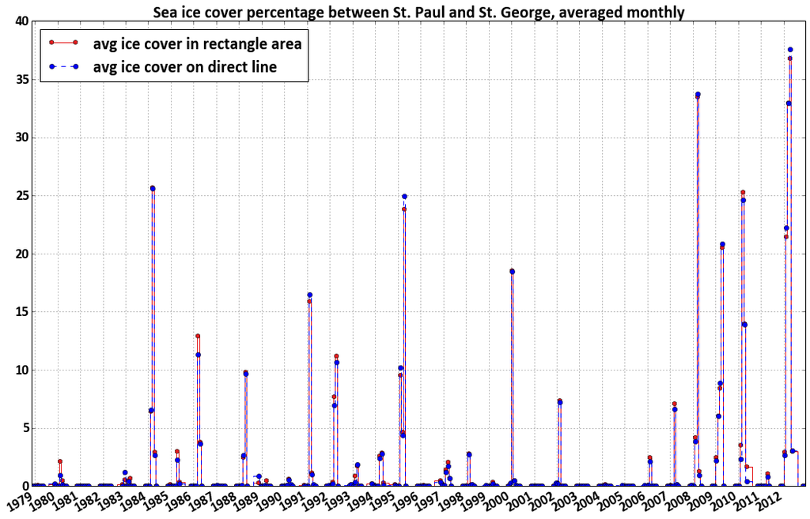

```python
SAFEOUT = False

monthx = [datetime.datetime(yy, mm, 15) for (yy, mm) in allmonths]
months    = MonthLocator(range(1,6) + [11, 12], bymonthday=1)
monthsFmt = DateFormatter("%b '%y")
years    = YearLocator()   # every year
yearsFmt = DateFormatter('%Y')
fig, ax = plt.subplots(figsize=(18, 12))
ax.plot_date(monthx, iceidx2, fmt='h', linestyle='-', drawstyle='steps-mid',  label='avg ice cover in rectangle area')
ax.plot_date(monthx, iceidx1, linestyle='--', drawstyle='steps-mid', label='avg ice cover on direct line')
ax.xaxis.set_major_locator(years)
ax.xaxis.set_major_formatter(yearsFmt)
ax.autoscale_view()
ax.set_color_cycle(colors[3:])
ax.grid(True)
ax.legend(loc='upper left')
ax.set_title("Sea ice cover percentage between St. Paul and St. George, averaged monthly")
fig.autofmt_xdate()
if SAVEOUT:
    outfn = "percentageindices_monthly01.png"
    outpath = os.path.join(outdir, outfn)
    plt.savefig(outpath, dpi=200, bbox_inches='tight')
```

Indices 3 and 4 need to be aggregated by year before plotting.

```python
iceidx31 = {}
iceidx41 = {}

def add_grouped(dic, key, item):
    try:
        dic[key] += item
    except KeyError:
        dic[key] = item
    return dic

for idx, yymm in enumerate(allmonths):
    if yymm[1] <= 6:
        iceidx31 = add_grouped(iceidx31, yymm[0], iceidx3[idx])
        iceidx41 = add_grouped(iceidx41, yymm[0], iceidx4[idx])
    else:
        iceidx31 = add_grouped(iceidx31, yymm[0]+1, iceidx3[idx])
        iceidx41 = add_grouped(iceidx41, yymm[0]+1, iceidx4[idx])
```

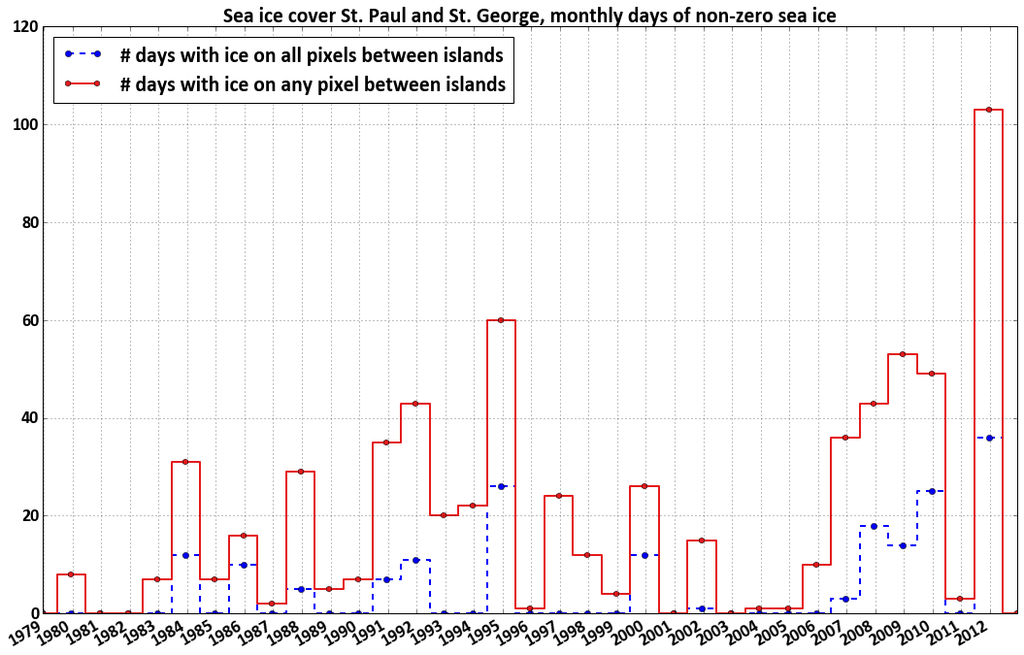

```python
SAVEOUT = False

years = range(1978, 2013)
yearx = [datetime.datetime(yy, mm, 15) for yy in years]
yearl    = YearLocator()   # every year
yearsFmt = DateFormatter('%Y')
fig, ax = plt.subplots(figsize=(18, 12))
ax.plot_date(yearx, iceidx31.values(), linestyle='--', linewidth=2, drawstyle='steps-mid', label='# days with ice on all pixels between islands')
ax.plot_date(yearx, iceidx41.values(), fmt='h', linestyle='-', linewidth=2, drawstyle='steps-mid', label='# days with ice on any pixel between islands')
ax.xaxis.set_major_locator(yearl)
ax.xaxis.set_major_formatter(yearsFmt)
ax.autoscale_view()
ax.grid(True)
ax.legend(loc='upper left')
ax.set_title("Sea ice cover St. Paul and St. George, monthly days of non-zero sea ice")
fig.autofmt_xdate()

if SAVEOUT:
    outfn = "daycountindices_yearly01.png"
    outpath = os.path.join(outdir, outfn)
    plt.savefig(outpath, dpi=200, bbox_inches='tight')
```

### Save and restore iceindex data

```python
outfile = os.path.join(outdir, "pribiloff_iceindices.npz")
np.savez(outfile,
         allmonths=np.array(allmonths),
         iceidx_straightline=np.array(iceidx1),
         iceidx_rectangle=np.array(iceidx2),
         iceidx_all=np.array(iceidx3),
         iceidx_any=np.array(iceidx4))
```

```python
datafile = os.path.join(outdir, "pribiloff_iceindices.npz")
with np.load(datafile) as saveddata:
    iceidx1 = saveddata['iceidx_straightline']
    iceidx2 = saveddata['iceidx_rectangle']
    iceidx3 = saveddata['iceidx_all']
    iceidx4 = saveddata['iceidx_any']
    allmonths = saveddata['allmonths']
```